# Regression

Anna Yeaton

Fall 2019

# Lab Section

In this lab, we will go over regression. We will be using the caret package in R. https://topepo.github.io/caret/train-models-by-tag.html

# Perfomance Metrics

## Residual

Deviation of the observed value to the estimated value (sample mean)
$$residual=y_i - \hat{y_i}$$
where $\hat{y_i}$ is the estimated value

## Mean Squared Error (MSE)

$$MSE=\frac{1}{n}\sum_{i=1}^{n}(y_i - \hat{y_i})^2$$

## Root Mean Squared Error (RMSE)

Same units as original data.

$$RMSE=\sqrt{MSE}$$

## L2 regularization : Ridge regression. Regularize by adding the sum of the coefficients, squared, to the function.

$$Ridge Regression=\sum_{i=1}^{n}(y_i - w_0 - \sum_{j=1}^{p}w_jx_{ij})^2 + \lambda\sum_{j=1}^p(w_j)^2$$

## L1 regularization : Lasso Regression. Regularize by adding the sum of the absolute value of the coefficients to the model. Coefficient estimates may be pushed to zero – Lasso can perform variable selection

$$Lasso Regression=\sum_{i=1}^{n}(y_i - w_0 - \sum_{j=1}^{p}w_jx_{ij})^2 + \lambda\sum_{j=1}^p|w_j|$$

### The broad steps of Machine learning in R.

1. Split the data into training and test. Set test aside.
2. Fit a good model to the training data.
3. See how your model did on the training data.
4. Test how your model performs on the test data.

# Regression

```r
length(airquality$Temp)
```

```
## [1] 153
```

1. Split data into training and test set (75% in train set, 25% in test set)

```r
train_regression <- createDataPartition(airquality$Wind, p=0.75, list = FALSE, times = 1)
air_train <- airquality[train_regression,]
air_test <- airquality[-train_regression,]

head(air_train)
```

|  | Ozone | Solar.R | Wind | Temp | Month | Day |
| --- | --- | --- | --- | --- | --- | --- |
| 2 | 36 | 118 | 8.0 | 72 | 5 | 2 |
| 3 | 12 | 149 | 12.6 | 74 | 5 | 3 |
| 4 | 18 | 313 | 11.5 | 62 | 5 | 4 |
| 6 | 28 | NA | 14.9 | 66 | 5 | 6 |
| 7 | 23 | 299 | 8.6 | 65 | 5 | 7 |
| 8 | 19 | 99 | 13.8 | 59 | 5 | 8 |

### Linear Regression

- Assumes a linear relationship.
- Independent variables should not be correlated (no mulitcollinearity)
- The number of observations should be greater than the number of independent variables.

$$RSS=\sum(y_i - \hat{y_i})^2$$
We will predict the response of the Temperature based on Wind.

This is the data we will fit a linear model to.

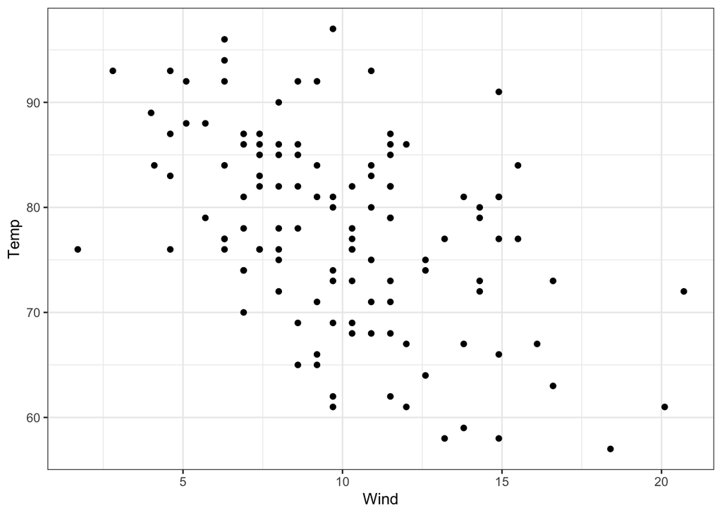

```r
ggplot(data = air_train) +
  geom_point(aes(x=Wind, y=Temp)) +
  theme_bw()
```

2. Create and fit a linear model to predict Temperature from Wind using the training set

```r
# develop model of temp onto wind, and make predictions based off training inputs
model_linr <- train(Temp~Wind, data = air_train, method = "lm")
model_linr
```

```
## Linear Regression
##
## 117 samples
##   1 predictor
##
## No pre-processing
## Resampling: Bootstrapped (25 reps)
## Summary of sample sizes: 117, 117, 117, 117, 117, 117, ...
## Resampling results:
##
##   RMSE      Rsquared   MAE
##   8.437932  0.2277285  7.122538
##
## Tuning parameter 'intercept' was held constant at a value of TRUE
```

```r
pred <- predict(model_linr, air_train)
```

3. Vizualize how your model performed on the train data by plotting the regression line on top of the train data points.

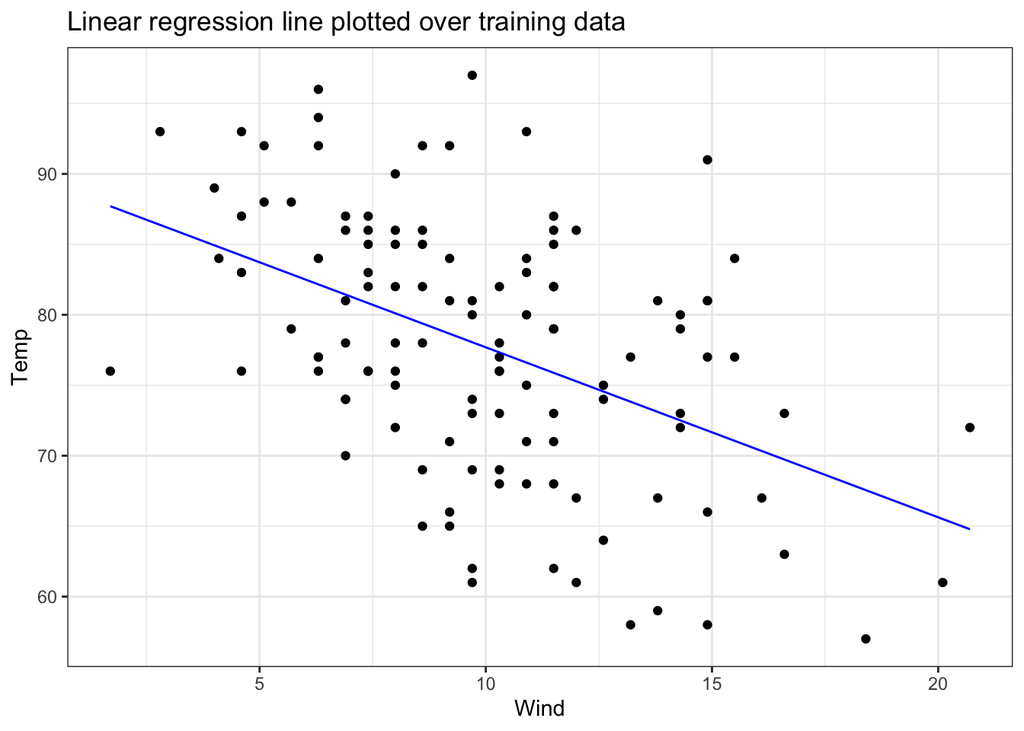

```r
ggplot(data = air_train) +
  geom_point(aes(x=Wind, y=Temp)) +
  theme_bw() +
  ggtitle("Linear regression line plotted over training data") +
  geom_line(aes(x = Wind, y = pred), color = "blue")
```

4. Explore how the model performs on the test data. For Linear Regression:
- The residuals should be close to zero.
- There should be equal variance around the regression line (homoscedasticity).
- Residuals should be normally distributed.
- Independent variables and residuals should not be correlated.

4 a) See how the model performs on the test data

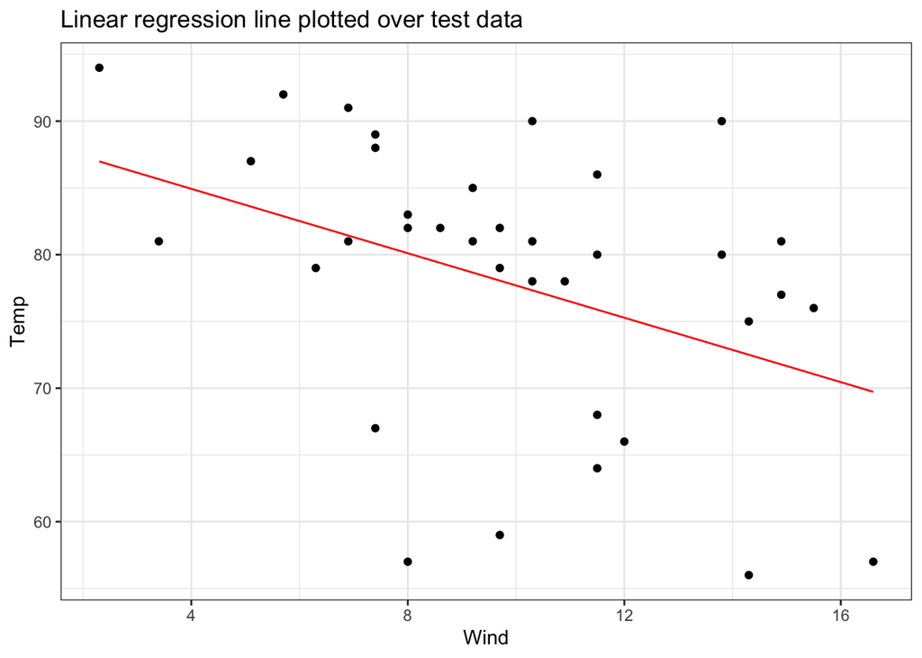

```r
pred_test <- predict(model_linr, air_test)

ggplot(data = air_test) +
  geom_point(aes(x=Wind, y=Temp)) +
  ggtitle("Linear regression line plotted over test data") +
  theme_bw() +
  geom_line(aes(x = Wind, y = pred_test), color = "red")
```

4 b) Look at the residuals. Are they close to zero?

```r
#look at the median residual value. Close to zero is best
#help(summary)
summary(model_linr)
```

```
##
## Call:
## lm(formula = .outcome ~ ., data = dat)
##
## Residuals:
##      Min       1Q   Median       3Q      Max
## -17.0545  -5.7798   0.4962   5.9442  19.2202
##
## Coefficients:
##             Estimate Std. Error t value Pr(>|t|)
## (Intercept)  89.7591     2.2603   39.71  < 2e-16 ***
## Wind         -1.2067     0.2136   -5.65 1.18e-07 ***
## ---
## Signif. codes:  0 '***' 0.001 '**' 0.01 '*' 0.05 '.' 0.1 ' ' 1
##
## Residual standard error: 8.191 on 115 degrees of freedom
## Multiple R-squared:  0.2173, Adjusted R-squared:  0.2105
## F-statistic: 31.92 on 1 and 115 DF,  p-value: 1.181e-07
```

4 c) Plot predicted temperature vs observed temperature. A strong model should show a strong correlation

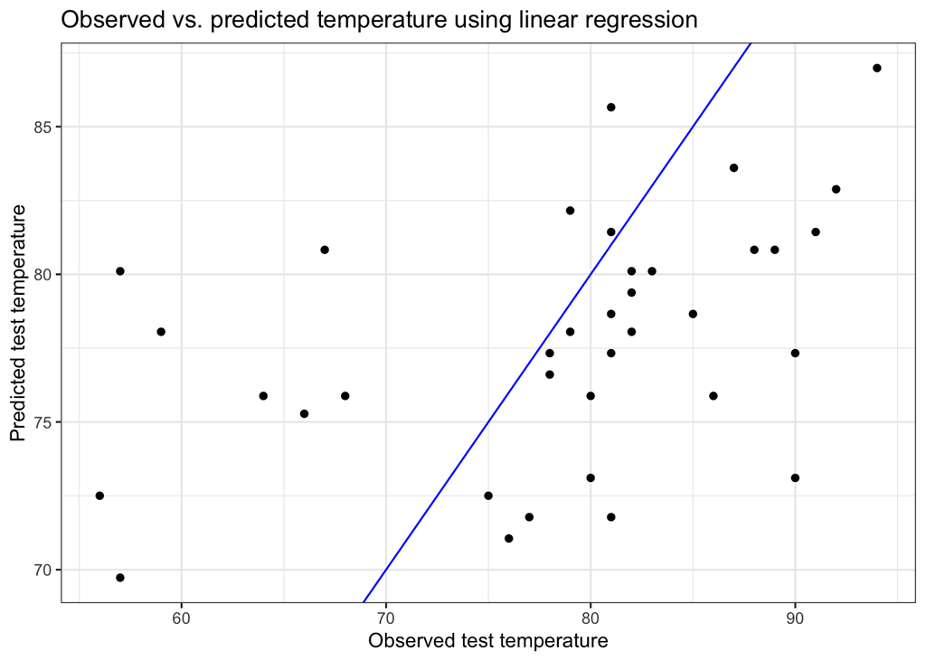

```r
ggplot() +
  geom_point(aes(x=air_test$Temp, y=pred_test)) +
  ggtitle("Observed vs. predicted temperature using linear regression") +
  xlab("Observed test temperature") +
  ylab("Predicted test temperature") +
  theme_bw() +
  geom_abline(intercept = 0, slope = 1, color = "blue")
```

**The oberved and predicted values don’t cluster tightly around the central line – it’s not a particularly strong model**

4 d) Visualize the predicted values in relation to the real data points. Look for homoscedasticity

```r
# Extract coefficients from the model
m_coef <- coef(model_linr$finalModel)
m_coef
```

```
## (Intercept)        Wind
##   89.759102   -1.206664
```

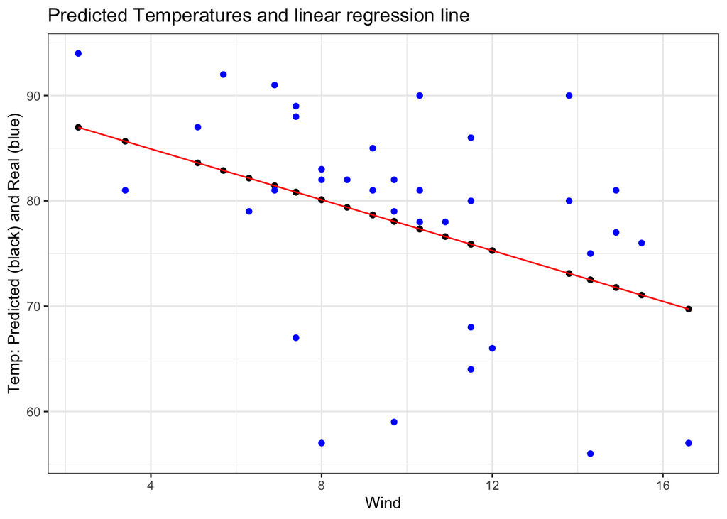

```r
pred_test <- predict(model_linr, air_test)


# plot the regression line on the predicted values
# plot the original test values
ggplot(data = air_test) +
  geom_point(aes(x=Wind, y=pred_test)) +
  geom_point(aes(x=Wind, y=Temp), color = "blue") +
  ggtitle("Predicted Temperatures and linear regression line") +
  ylab("Temp: Predicted (black) and Real (blue)") +
  theme_bw() +
  geom_line(aes(x = Wind, y = pred_test), color = "red")
```

4 e) Residuals should be normally distributed. Plot the density of the residuals

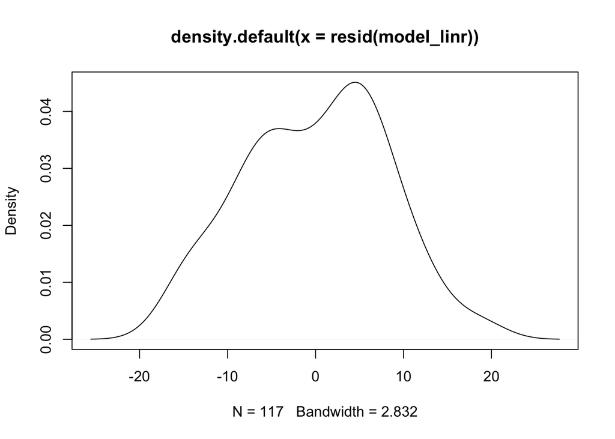

```r
#residuals_lin <- residuals(model_linr$finalModel)
plot(density(resid(model_linr)))
```

```r
# ggplot(data=residvpredict) +
#   geom_density(aes(residual))
```

4 f) Independent variables and residuals should not be correlated

```r
cor.test(air_train$Wind, resid(model_linr))
```

```
##
##  Pearson's product-moment correlation
##
## data:  air_train$Wind and resid(model_linr)
## t = 8.6687e-16, df = 115, p-value = 1
## alternative hypothesis: true correlation is not equal to 0
## 95 percent confidence interval:
##  -0.181533  0.181533
## sample estimates:
##          cor
## 8.083617e-17
```

**P-value >> 0.05, so we cannot reject the null hypothesis that residuals and independent variables are independent**

### Linear Regression with Regularization

5. Create a linear model using L1 or L2 regularization to predict Temperature from Wind and Month variables. Plot your predicted values and the real Y values on the same plot.

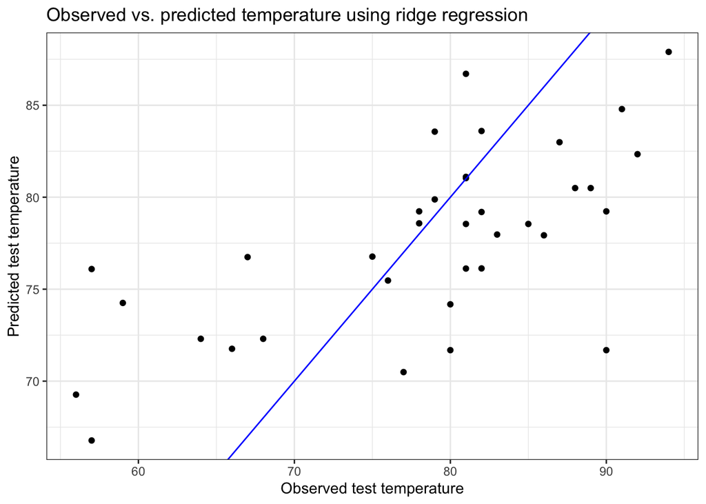

```r
# L2 regression:
ctrl =  trainControl(method = "boot", 15)
model_l1 <- train(Temp~Wind + Month, data = air_train, method = 'ridge', trControl = ctrl)
pred_test <- predict(model_l1, air_test)

ggplot() +
  geom_point(aes(x=air_test$Temp, y=pred_test)) +
  ggtitle("Observed vs. predicted temperature using ridge regression") +
  xlab("Observed test temperature") +
  ylab("Predicted test temperature") +
  theme_bw() +
  geom_abline(intercept = 0, slope = 1, color = "blue")
```